# Applied Machine Learning in Economics Exercise 1

Nasim Gholizadeh

# Question 1

Explain whether each scenario is a classification or regression problem, and indicate whether we are most interested in inference or prediction. Finally, provide $n$ and $p$.

1. We collect a set of data on the top 500 firms in the US. For each firm we record profit, number of employees, industry and the CEO salary. We are interested in understanding which factors affect CEO salary.
2. We are considering launching a new product and wish to know whether it will be a *success* or a *failure*. We collect data on 20 similar products that were previously launched. For each product we have recorded whether it was a success or failure, price charged for the product, marketing budget, competition price, and ten other variables.
3. We are interested in predicting the % change in the USD/Euro exchange rate in relation to the weekly changes in the world stock markets. Hence we collect weekly data for all of 2012. For each week we record the % change in the USD/Euro, the % change in the US market, the % change in the British market, and the % change in the German market.

# Answer 1

1. Regression problem as the response variable is quantitative. We are interested in inference because we are interested in understanding which factors affect CEO salary. n : 500 (500 firms). n=500 p : 3 (profit, number of employees, and industry). p = 3
2. Classification problem since the response variable is a binary value (success or failure). We are interested in prediction, whether the new product will be a success or a failure. n : 20 (20 similar products). n=20 p : 13 (price charged for the product, marketing budget, competition price, and 10 other variables). p = 13
3. Regression problem because the response variable (% change in the USD/Euro) is a quantitative value. We are interested in prediction of the % change in the USD/Euro exchange rate in relation to the weekly changes in the world stock markets. n : 52 (weekly data for all of 2012). n=52 p : 3 (the % change in the US market, the % change in the British market, and the % change in the German market). p = 3

# Question 2 (applied)

This exercise relates to the `College` data set, It contains a number of variables for 777 different universities and colleges in the US. The variables are

- `Private`: Public/private indicator
- `Apps`: Number of applications received
- `Accept`: Number of applicants accepted
- `Enroll`: Number of new students enrolled
- `Top10perc`: New students from top 10
- `Top25perc`: New students from top 25
- `F.Undergrad`: Number of full-time undergraduates
- `P.Undergrad`: Number of part-time undergraduates
- `Outstate`: Out-of-state tuition
- `Room.Board`: Room and board costs
- `Books`: Estimated book costs
- `Personal`: Estimated personal spending
- `PhD`: Percent of faculty with Ph.D.’s
- `Terminal`: Percent of faculty with terminal degree
- `S.F.Ratio`: Student/faculty ratio
- `perc.alumni`: Percent of alumni who donate
- `Expend`: Instructional expenditure per student
- `Grad.Rate`: Graduation rate

Before reading the data into R, it can be viewed in Excel or a text editor.

1. Use the `read.csv()` function to read the data into `R`. Call the loaded data `college`. Make sure that you have the directory set to the correct location for the data. The `R` commands `getwd()` and `setwd()` may be helpful.
2. Look at the data using the `head()` function. You should notice that the first column is just the name of each university. We don’t really want R to treat this as data. However, it may be handy to have these names for later. Try the following commands:

```r
rownames(college) <- college[, 1]
View(college)
```

You should see that there is now a `row.names` column with the name of each university recorded. This means that `R` has given each row a name corresponding to the appropriate university. `R` will not try to perform calculations on the row names. However, we still need to eliminate the first column in the data where the names are stored. Try

```r
college <- college[, -1]
View(college)
```

Now you should see that the first data column is `Private`. Note that another column labeled `row.names` now appears before the `Private` column. However, this is not a data column but rather the name that `R` is giving to each row.

1. Use the `summary()` function to produce a numerical summary of the variables in the data set.
2. Use the `pairs()` function to produce a scatterplot matrix of the first ten columns or variables of the data. Recall that you can reference the first ten columns of a matrix `A` using `A[,1:10]`.
3. Use the `plot()` function to produce side-by-side boxplots of `Outstate` versus `Private`.
4. Create a new qualitative variable, called `Elite`, by binning the `Top10perc` variable. We are going to divide universities into two groups based on whether or not the proportion of students coming from the top 10% of their high school classes exceeds 50%.

```r
Elite <- rep("No", nrow(college))
Elite[college$Top10perc > 50] <- "Yes"
Elite <- as.factor(Elite)
college <- data.frame(college, Elite)
```

Use the `summary()` function to see how many elite universities there are. Now use the `plot()` function to produce side-by-side boxplots of `Outstate` versus `Elite`.

22. Use the `hist()` function to produce some histograms with differing numbers of bins for a few of the quantitative variables. You may find the command `par(mfrow = c(2, 2))` useful: it will divide the print window into four regions so that four plots can be made simultaneously. Modifying the arguments to this function will divide the screen in other ways.
6. Continue exploring the data, and **provide a brief summary** of what you discover.

# Answer 2 (applied)

```r
college <- read.csv("College.csv", stringsAsFactors=T)
```

```r
rownames(college) <- college[, 1]
college <- college[, -1]
head(college)
```

```
##                              Private Apps Accept Enroll Top10perc Top25perc
## Abilene Christian University     Yes 1660   1232    721        23        52
## Adelphi University               Yes 2186   1924    512        16        29
## Adrian College                   Yes 1428   1097    336        22        50
## Agnes Scott College              Yes  417    349    137        60        89
## Alaska Pacific University        Yes  193    146     55        16        44
## Albertson College                Yes  587    479    158        38        62
##                              F.Undergrad P.Undergrad Outstate Room.Board Books
## Abilene Christian University        2885         537     7440       3300   450
## Adelphi University                  2683        1227    12280       6450   750
## Adrian College                      1036          99    11250       3750   400
## Agnes Scott College                  510          63    12960       5450   450
## Alaska Pacific University            249         869     7560       4120   800
## Albertson College                    678          41    13500       3335   500
##                              Personal PhD Terminal S.F.Ratio perc.alumni Expend
## Abilene Christian University     2200  70       78      18.1          12   7041
## Adelphi University               1500  29       30      12.2          16  10527
## Adrian College                   1165  53       66      12.9          30   8735
## Agnes Scott College               875  92       97       7.7          37  19016
## Alaska Pacific University        1500  76       72      11.9           2  10922
## Albertson College                 675  67       73       9.4          11   9727
##                              Grad.Rate
## Abilene Christian University        60
## Adelphi University                  56
## Adrian College                      54
## Agnes Scott College                 59
## Alaska Pacific University           15
## Albertson College                   55
```

```r
summary(college)
```

```
##  Private        Apps           Accept          Enroll       Top10perc
##  No :212   Min.   :   81   Min.   :   72   Min.   :  35   Min.   : 1.00
##  Yes:565   1st Qu.:  776   1st Qu.:  604   1st Qu.: 242   1st Qu.:15.00
##            Median : 1558   Median : 1110   Median : 434   Median :23.00
##            Mean   : 3002   Mean   : 2019   Mean   : 780   Mean   :27.56
##            3rd Qu.: 3624   3rd Qu.: 2424   3rd Qu.: 902   3rd Qu.:35.00
##            Max.   :48094   Max.   :26330   Max.   :6392   Max.   :96.00
##    Top25perc      F.Undergrad     P.Undergrad         Outstate
##  Min.   :  9.0   Min.   :  139   Min.   :    1.0   Min.   : 2340
##  1st Qu.: 41.0   1st Qu.:  992   1st Qu.:   95.0   1st Qu.: 7320
##  Median : 54.0   Median : 1707   Median :  353.0   Median : 9990
##  Mean   : 55.8   Mean   : 3700   Mean   :  855.3   Mean   :10441
##  3rd Qu.: 69.0   3rd Qu.: 4005   3rd Qu.:  967.0   3rd Qu.:12925
##  Max.   :100.0   Max.   :31643   Max.   :21836.0   Max.   :21700
##    Room.Board       Books           Personal         PhD
##  Min.   :1780   Min.   :  96.0   Min.   : 250   Min.   :  8.00
##  1st Qu.:3597   1st Qu.: 470.0   1st Qu.: 850   1st Qu.: 62.00
##  Median :4200   Median : 500.0   Median :1200   Median : 75.00
##  Mean   :4358   Mean   : 549.4   Mean   :1341   Mean   : 72.66
##  3rd Qu.:5050   3rd Qu.: 600.0   3rd Qu.:1700   3rd Qu.: 85.00
##  Max.   :8124   Max.   :2340.0   Max.   :6800   Max.   :103.00
##     Terminal       S.F.Ratio      perc.alumni        Expend
##  Min.   : 24.0   Min.   : 2.50   Min.   : 0.00   Min.   : 3186
##  1st Qu.: 71.0   1st Qu.:11.50   1st Qu.:13.00   1st Qu.: 6751
##  Median : 82.0   Median :13.60   Median :21.00   Median : 8377
##  Mean   : 79.7   Mean   :14.09   Mean   :22.74   Mean   : 9660
##  3rd Qu.: 92.0   3rd Qu.:16.50   3rd Qu.:31.00   3rd Qu.:10830
##  Max.   :100.0   Max.   :39.80   Max.   :64.00   Max.   :56233
##    Grad.Rate
##  Min.   : 10.00
##  1st Qu.: 53.00
##  Median : 65.00
##  Mean   : 65.46
##  3rd Qu.: 78.00
##  Max.   :118.00
```

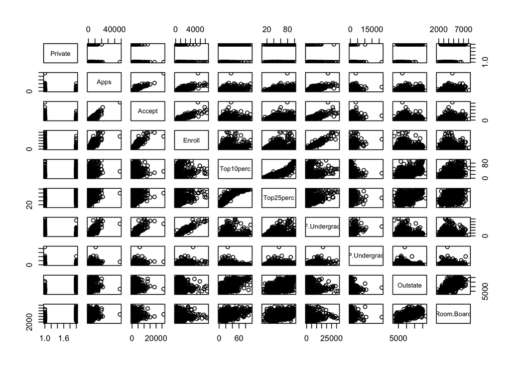

```r
pairs(college[, 1:10])
```

iii)

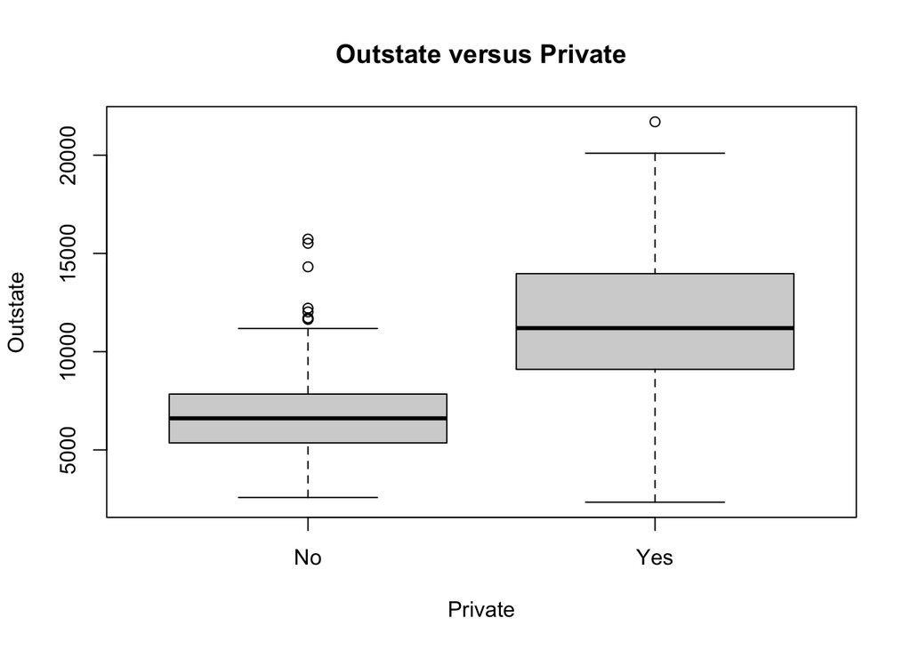

```r
plot(college$Private, college$Outstate, main = "Outstate versus Private",
    xlab = "Private", ylab = "Outstate")
```

```r
Elite <- rep("No", nrow(college))
Elite[college$Top10perc > 50] <- "Yes"
Elite <- as.factor(Elite)
college <- data.frame(college, Elite)
summary(college$Elite)
```

```
##  No Yes
## 699  78
```

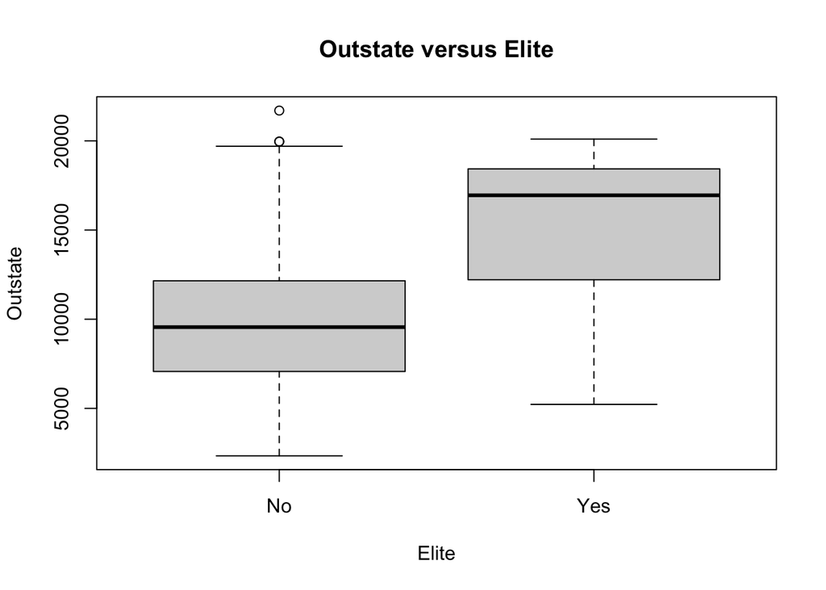

```r
plot(college$Elite, college$Outstate, main = "Outstate versus Elite",
    xlab = "Elite", ylab = "Outstate")
```

# boxplot(college$Outstate ~ college$Elite, main = “Outstate versus Elite”,

# xlab = “Elite”, ylab = “Outstate”)

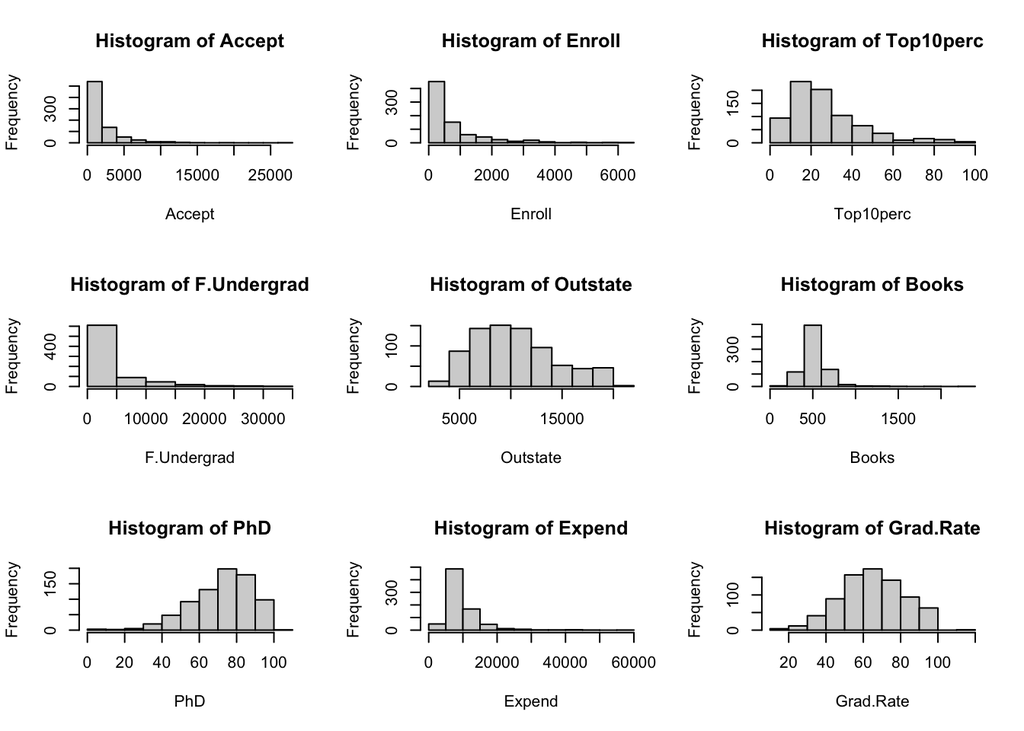

```r
par(mfrow = c(3,3))
hist(college$Accept, main = "Histogram of Accept", xlab = "Accept")
hist(college$Enroll, main = "Histogram of Enroll", xlab = "Enroll")
hist(college$Top10perc, main = "Histogram of Top10perc", xlab = "Top10perc")
hist(college$F.Undergrad, main = "Histogram of F.Undergrad", xlab = "F.Undergrad")
hist(college$Outstate, main = "Histogram of Outstate", xlab = "Outstate")
hist(college$Books, main = "Histogram of Books", xlab = "Books")
hist(college$PhD, main = "Histogram of PhD", xlab = "PhD")
hist(college$Expend, main = "Histogram of Expend", xlab = "Expend")
hist(college$Grad.Rate, main = "Histogram of Grad.Rate", xlab = "Grad.Rate")
```

vi)

```r
ols.fit <- lm(Grad.Rate ~ Apps + Top25perc + Personal + F.Undergrad + perc.alumni + Expend,
            data = college)
summary(ols.fit)
```

```
##
## Call:
## lm(formula = Grad.Rate ~ Apps + Top25perc + Personal + F.Undergrad +
##     perc.alumni + Expend, data = college)
##
## Residuals:
##     Min      1Q  Median      3Q     Max
## -59.822  -8.247  -0.008   7.947  56.838
##
## Coefficients:
##               Estimate Std. Error t value Pr(>|t|)
## (Intercept) 45.9655561  1.9429486  23.658  < 2e-16 ***
## Apps         0.0015010  0.0002415   6.215 8.39e-10 ***
## Top25perc    0.2346237  0.0316370   7.416 3.19e-13 ***
## Personal    -0.0031989  0.0007787  -4.108 4.42e-05 ***
## F.Undergrad -0.0010708  0.0001907  -5.616 2.73e-08 ***
## perc.alumni  0.4012601  0.0480820   8.345 3.28e-16 ***
## Expend       0.0001061  0.0001186   0.895    0.371
## ---
## Signif. codes:  0 '***' 0.001 '**' 0.01 '*' 0.05 '.' 0.1 ' ' 1
##
## Residual standard error: 13.46 on 770 degrees of freedom
## Multiple R-squared:  0.3912, Adjusted R-squared:  0.3865
## F-statistic: 82.47 on 6 and 770 DF,  p-value: < 2.2e-16
```